# Project: Investigate a Dataset - [No-show appointments]

- Introduction
- Data Wrangling
- Exploratory Data Analysis
- Conclusions

## Introduction

### Dataset Description

**we have csv file include dataset collects information from 100k medical appointments in Brazil and is focused on the question of whether or not patients show up for their appointment.**

The file includes the following columns:

*PatientId*__*The patient's insurance number.

*AppointmentID____Medical examination reservation number.

*Gender**__**The gender of the patient (male or female).

*ScheduledDay**_**what day the patient set up their appointment.

*AppointmentDay___The date of the medical examination.

*Age**_**patient age.

*Neighborhood**_**indicates the location of the hospital.

*Scholarship**__**indicates whether or not the patient is enrolled in Brasilian welfare program Bolsa Família.

*Hipertension**_**The patient is suffering from high blood pressure.

*Diabetes**_**The patient suffers from Diabetes mellitus.

*Alcoholism**___**The patient is addicted to alcohol.

*Handcap**__**The patient has some type of disability.

*SMS_received**_**indicates that the patient received a message regarding the appointment date or not.

*No-show**__**indicates whether the patient attended the examination appointment or not.(it says ‘No’ if the patient showed up to their appointment, and ‘Yes’ if they did not show up).

### Question(s) for Analysis

What is the percentage of patients who did not attend?

Is the female more committed to appointment or male?

Does the patient's failure to reach the appointment message make him not attend?

Is it in the middle of the week when the patient is busy and cannot come for the appointment?

What is the percentage of patients who did not attend and have Hypertension?

What effect does WaitingTime have on patient attendance?

Is there a relationship between Neighborhood and attending the appointment?

Is there a relationship between the patient's age and attendance to the appointment?

```python
# Use this cell to set up import statements for all of the packages that you
#   plan to use.

# Remember to include a 'magic word' so that your visualizations are plotted
#   inline with the notebook. See this page for more:
#   http://ipython.readthedocs.io/en/stable/interactive/magics.html
import numpy as np
import pandas as pd
import matplotlib.pyplot as plt
import seaborn as sns
% matplotlib inline
```

```python
# Upgrade pandas to use dataframe.explode() function.
!pip install --upgrade pandas
```

## Data Wrangling

### General Properties

```python
# Load your data and print out a few lines. Perform operations to inspect data
#   types and look for instances of missing or possibly errant data.
# Load your data and print out a few lines. Perform operations to inspect data.
df = pd.read_csv("Database_No_show_appointments/noshowappointments-kagglev2-may-2016.csv")
df.head()
```

|  | PatientId | AppointmentID | Gender | ScheduledDay | AppointmentDay | Age | Neighbourhood | Scholarship | Hipertension | Diabetes | Alcoholism | Handcap | SMS_received | No-show |
| --- | --- | --- | --- | --- | --- | --- | --- | --- | --- | --- | --- | --- | --- | --- |
| 0 | 2.987250e+13 | 5642903 | F | 2016-04-29T18:38:08Z | 2016-04-29T00:00:00Z | 62 | JARDIM DA PENHA | 0 | 1 | 0 | 0 | 0 | 0 | No |
| 1 | 5.589978e+14 | 5642503 | M | 2016-04-29T16:08:27Z | 2016-04-29T00:00:00Z | 56 | JARDIM DA PENHA | 0 | 0 | 0 | 0 | 0 | 0 | No |
| 2 | 4.262962e+12 | 5642549 | F | 2016-04-29T16:19:04Z | 2016-04-29T00:00:00Z | 62 | MATA DA PRAIA | 0 | 0 | 0 | 0 | 0 | 0 | No |
| 3 | 8.679512e+11 | 5642828 | F | 2016-04-29T17:29:31Z | 2016-04-29T00:00:00Z | 8 | PONTAL DE CAMBURI | 0 | 0 | 0 | 0 | 0 | 0 | No |
| 4 | 8.841186e+12 | 5642494 | F | 2016-04-29T16:07:23Z | 2016-04-29T00:00:00Z | 56 | JARDIM DA PENHA | 0 | 1 | 1 | 0 | 0 | 0 | No |

```python
#to Know the size of the data.
df.shape
```

```
(110527, 14)
```

```python
#To make sure that all data is available and that there is no empty data.
df.info()
```

```
<class 'pandas.core.frame.DataFrame'>
RangeIndex: 110527 entries, 0 to 110526
Data columns (total 14 columns):
 #   Column          Non-Null Count   Dtype
---  ------          --------------   -----
 0   PatientId       110527 non-null  float64
 1   AppointmentID   110527 non-null  int64
 2   Gender          110527 non-null  object
 3   ScheduledDay    110527 non-null  object
 4   AppointmentDay  110527 non-null  object
 5   Age             110527 non-null  int64
 6   Neighbourhood   110527 non-null  object
 7   Scholarship     110527 non-null  int64
 8   Hipertension    110527 non-null  int64
 9   Diabetes        110527 non-null  int64
 10  Alcoholism      110527 non-null  int64
 11  Handcap         110527 non-null  int64
 12  SMS_received    110527 non-null  int64
 13  No-show         110527 non-null  object
dtypes: float64(1), int64(8), object(5)
memory usage: 11.8+ MB
```

Note: From the previous data, it is clear that there is no missing data

```python
#to find duplicate rows
df.duplicated().sum()
```

```
0
```

Note: There is no duplicate data.

```python
#to find data averages
df.describe()
```

|  | PatientId | AppointmentID | Age | Scholarship | Hipertension | Diabetes | Alcoholism | Handcap | SMS_received |
| --- | --- | --- | --- | --- | --- | --- | --- | --- | --- |
| count | 1.105270e+05 | 1.105270e+05 | 110527.000000 | 110527.000000 | 110527.000000 | 110527.000000 | 110527.000000 | 110527.000000 | 110527.000000 |
| mean | 1.474963e+14 | 5.675305e+06 | 37.088874 | 0.098266 | 0.197246 | 0.071865 | 0.030400 | 0.022248 | 0.321026 |
| std | 2.560949e+14 | 7.129575e+04 | 23.110205 | 0.297675 | 0.397921 | 0.258265 | 0.171686 | 0.161543 | 0.466873 |
| min | 3.921784e+04 | 5.030230e+06 | -1.000000 | 0.000000 | 0.000000 | 0.000000 | 0.000000 | 0.000000 | 0.000000 |
| 25% | 4.172614e+12 | 5.640286e+06 | 18.000000 | 0.000000 | 0.000000 | 0.000000 | 0.000000 | 0.000000 | 0.000000 |
| 50% | 3.173184e+13 | 5.680573e+06 | 37.000000 | 0.000000 | 0.000000 | 0.000000 | 0.000000 | 0.000000 | 0.000000 |
| 75% | 9.439172e+13 | 5.725524e+06 | 55.000000 | 0.000000 | 0.000000 | 0.000000 | 0.000000 | 0.000000 | 1.000000 |
| max | 9.999816e+14 | 5.790484e+06 | 115.000000 | 1.000000 | 1.000000 | 1.000000 | 1.000000 | 4.000000 | 1.000000 |

Note: There is a value for the patient's age in negative (-1), I will delete it in the delete section.

```python
#To see the entries for each column.
for i in df[['Gender' ,'Scholarship', 'Hipertension', 'Diabetes', 'Alcoholism', 'Handcap', 'SMS_received', 'No-show']]:
    print(df[i].value_counts())
```

```
F    71840
M    38687
Name: Gender, dtype: int64
0    99666
1    10861
Name: Scholarship, dtype: int64
0    88726
1    21801
Name: Hipertension, dtype: int64
0    102584
1      7943
Name: Diabetes, dtype: int64
0    107167
1      3360
Name: Alcoholism, dtype: int64
0    108286
1      2042
2       183
3        13
4         3
Name: Handcap, dtype: int64
0    75045
1    35482
Name: SMS_received, dtype: int64
No     88208
Yes    22319
Name: No-show, dtype: int64
```

Note: From the previous data, we conclude that each of its columns contains only two values, except for the Handcap column, which contains 4 values (1, 2, 3, 4), but I see that the values are (2, 3, 4).

```python
#To find out if there are patients who have booked more than once.
df["PatientId"].value_counts()
```

```
8.221459e+14    88
9.963767e+10    84
2.688613e+13    70
3.353478e+13    65
2.584244e+11    62
                ..
1.222828e+13     1
6.821231e+11     1
7.163981e+14     1
9.798964e+14     1
2.724571e+11     1
Name: PatientId, Length: 62299, dtype: int64
```

Note: The number of samples is 110,527, but we have a patient number of 62,299 patients, which means that there are 48,228 patients booked more than once.

```python
# To see the column entries and see the number of locations
df["Neighbourhood"].value_counts()
```

```
JARDIM CAMBURI                 7717
MARIA ORTIZ                    5805
RESISTÊNCIA                    4431
JARDIM DA PENHA                3877
ITARARÉ                        3514
                               ...
ILHA DO BOI                      35
ILHA DO FRADE                    10
AEROPORTO                         8
ILHAS OCEÂNICAS DE TRINDADE       2
PARQUE INDUSTRIAL                 1
Name: Neighbourhood, Length: 81, dtype: int64
```

Note: We have 81 locations .

```python
# To find out the time period whose data is being analyzed.
df["AppointmentDay"].sort_values()
```

```
0        2016-04-29T00:00:00Z
2151     2016-04-29T00:00:00Z
2152     2016-04-29T00:00:00Z
2153     2016-04-29T00:00:00Z
2154     2016-04-29T00:00:00Z
                 ...
92055    2016-06-08T00:00:00Z
99217    2016-06-08T00:00:00Z
99218    2016-06-08T00:00:00Z
99224    2016-06-08T00:00:00Z
91900    2016-06-08T00:00:00Z
Name: AppointmentDay, Length: 110527, dtype: object
```

Note: From the previous data, it is clear that the Appointment period is from 2016-4-29 to 2016-6-8 .

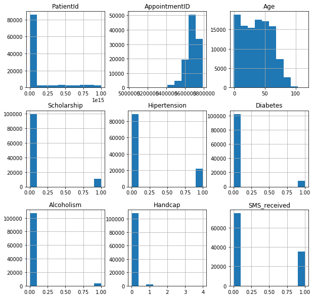

```python
#general overview.
df.hist(figsize=(10,10));
```

Note: from the previous data that it is clear that the columns (Diabetes, Alcoholism, Handcap) have little effect on the data, so I will delete them in the delete section.

### Data Cleaning

#### Modify the data

```python
#The No-show column has a confusing name So I will change his name to show.
df.rename(columns={"No-show":"Show"},inplace=True)
df.info()
```

```
<class 'pandas.core.frame.DataFrame'>
RangeIndex: 110527 entries, 0 to 110526
Data columns (total 14 columns):
 #   Column          Non-Null Count   Dtype
---  ------          --------------   -----
 0   PatientId       110527 non-null  float64
 1   AppointmentID   110527 non-null  int64
 2   Gender          110527 non-null  object
 3   ScheduledDay    110527 non-null  object
 4   AppointmentDay  110527 non-null  object
 5   Age             110527 non-null  int64
 6   Neighbourhood   110527 non-null  object
 7   Scholarship     110527 non-null  int64
 8   Hipertension    110527 non-null  int64
 9   Diabetes        110527 non-null  int64
 10  Alcoholism      110527 non-null  int64
 11  Handcap         110527 non-null  int64
 12  SMS_received    110527 non-null  int64
 13  Show            110527 non-null  object
dtypes: float64(1), int64(8), object(5)
memory usage: 11.8+ MB
```

```python
#Modify the show column values to No=Yes and Yes=No to make it more clear.
df["Show"].replace({"Yes":"No", "No":"Yes"}, inplace=True)
df["Show"].value_counts()
```

```
Yes    88208
No     22319
Name: Show, dtype: int64
```

```python
#AppointmentDay column without time I will edit and delete the time.
df["AppointmentDay"] = pd.to_datetime(df["AppointmentDay"]).dt.date
#also delete the time from the ScheduledDay column.
df["ScheduledDay"] = pd.to_datetime(df["ScheduledDay"]).dt.date
df.head()
```

|  | PatientId | AppointmentID | Gender | ScheduledDay | AppointmentDay | Age | Neighbourhood | Scholarship | Hipertension | Diabetes | Alcoholism | Handcap | SMS_received | Show |
| --- | --- | --- | --- | --- | --- | --- | --- | --- | --- | --- | --- | --- | --- | --- |
| 0 | 2.987250e+13 | 5642903 | F | 2016-04-29 | 2016-04-29 | 62 | JARDIM DA PENHA | 0 | 1 | 0 | 0 | 0 | 0 | Yes |
| 1 | 5.589978e+14 | 5642503 | M | 2016-04-29 | 2016-04-29 | 56 | JARDIM DA PENHA | 0 | 0 | 0 | 0 | 0 | 0 | Yes |
| 2 | 4.262962e+12 | 5642549 | F | 2016-04-29 | 2016-04-29 | 62 | MATA DA PRAIA | 0 | 0 | 0 | 0 | 0 | 0 | Yes |
| 3 | 8.679512e+11 | 5642828 | F | 2016-04-29 | 2016-04-29 | 8 | PONTAL DE CAMBURI | 0 | 0 | 0 | 0 | 0 | 0 | Yes |
| 4 | 8.841186e+12 | 5642494 | F | 2016-04-29 | 2016-04-29 | 56 | JARDIM DA PENHA | 0 | 1 | 1 | 0 | 0 | 0 | Yes |

#### Addition Data

```python
#Add a column to indicate the number of waiting days for a medical examination.
df["WaitingTime"] = (df["AppointmentDay"] - df["ScheduledDay"]).dt.days
df["WaitingTime"].value_counts()
```

```
 0      38563
 2       6725
 4       5290
 1       5213
 7       4906
        ...
 117        1
 146        1
 82         1
-6          1
 127        1
Name: WaitingTime, Length: 131, dtype: int64
```

Note: There is a negative WaitingTime, and this is illogical. I will delete it in the delete section.

```python
df.info()
```

```
<class 'pandas.core.frame.DataFrame'>
RangeIndex: 110527 entries, 0 to 110526
Data columns (total 15 columns):
 #   Column          Non-Null Count   Dtype
---  ------          --------------   -----
 0   PatientId       110527 non-null  float64
 1   AppointmentID   110527 non-null  int64
 2   Gender          110527 non-null  object
 3   ScheduledDay    110527 non-null  object
 4   AppointmentDay  110527 non-null  object
 5   Age             110527 non-null  int64
 6   Neighbourhood   110527 non-null  object
 7   Scholarship     110527 non-null  int64
 8   Hipertension    110527 non-null  int64
 9   Diabetes        110527 non-null  int64
 10  Alcoholism      110527 non-null  int64
 11  Handcap         110527 non-null  int64
 12  SMS_received    110527 non-null  int64
 13  Show            110527 non-null  object
 14  WaitingTime     110527 non-null  int64
dtypes: float64(1), int64(9), object(5)
memory usage: 12.6+ MB
```

```python
#Add a column with the name of the day of the week to the AppointmentDay column.
df["AppointmentDay_name"] = pd.to_datetime(df["AppointmentDay"]).dt.day_name()
df.head()
```

|  | PatientId | AppointmentID | Gender | ScheduledDay | AppointmentDay | Age | Neighbourhood | Scholarship | Hipertension | Diabetes | Alcoholism | Handcap | SMS_received | Show | WaitingTime | AppointmentDay_name |
| --- | --- | --- | --- | --- | --- | --- | --- | --- | --- | --- | --- | --- | --- | --- | --- | --- |
| 0 | 2.987250e+13 | 5642903 | F | 2016-04-29 | 2016-04-29 | 62 | JARDIM DA PENHA | 0 | 1 | 0 | 0 | 0 | 0 | Yes | 0 | Friday |
| 1 | 5.589978e+14 | 5642503 | M | 2016-04-29 | 2016-04-29 | 56 | JARDIM DA PENHA | 0 | 0 | 0 | 0 | 0 | 0 | Yes | 0 | Friday |
| 2 | 4.262962e+12 | 5642549 | F | 2016-04-29 | 2016-04-29 | 62 | MATA DA PRAIA | 0 | 0 | 0 | 0 | 0 | 0 | Yes | 0 | Friday |
| 3 | 8.679512e+11 | 5642828 | F | 2016-04-29 | 2016-04-29 | 8 | PONTAL DE CAMBURI | 0 | 0 | 0 | 0 | 0 | 0 | Yes | 0 | Friday |
| 4 | 8.841186e+12 | 5642494 | F | 2016-04-29 | 2016-04-29 | 56 | JARDIM DA PENHA | 0 | 1 | 1 | 0 | 0 | 0 | Yes | 0 | Friday |

#### Delete data

```python
#I will drop all the cells I don't need it in my analyzes.
df.drop(["AppointmentID","ScheduledDay","Scholarship","Diabetes","Alcoholism","Handcap"] , axis =1 , inplace = True)
df.info()
```

```
<class 'pandas.core.frame.DataFrame'>
RangeIndex: 110527 entries, 0 to 110526
Data columns (total 10 columns):
 #   Column               Non-Null Count   Dtype
---  ------               --------------   -----
 0   PatientId            110527 non-null  float64
 1   Gender               110527 non-null  object
 2   AppointmentDay       110527 non-null  object
 3   Age                  110527 non-null  int64
 4   Neighbourhood        110527 non-null  object
 5   Hipertension         110527 non-null  int64
 6   SMS_received         110527 non-null  int64
 7   Show                 110527 non-null  object
 8   WaitingTime          110527 non-null  int64
 9   AppointmentDay_name  110527 non-null  object
dtypes: float64(1), int64(4), object(5)
memory usage: 8.4+ MB
```

```python
# The number of the row in which the patient's age is negative
df.query('Age == -1')
```

|  | PatientId | Gender | AppointmentDay | Age | Neighbourhood | Hipertension | SMS_received | Show | WaitingTime | AppointmentDay_name |
| --- | --- | --- | --- | --- | --- | --- | --- | --- | --- | --- |
| 99832 | 4.659432e+14 | F | 2016-06-06 | -1 | ROMÃO | 0 | 0 | Yes | 0 | Monday |

```python
#Delete the negative patient age value.
df.drop(index = 99832 ,inplace=True)
#To make sure the required value is deleted.
df.describe()
```

|  | PatientId | Age | Hipertension | SMS_received | WaitingTime |
| --- | --- | --- | --- | --- | --- |
| count | 1.105260e+05 | 110526.000000 | 110526.000000 | 110526.000000 | 110526.000000 |
| mean | 1.474934e+14 | 37.089219 | 0.197248 | 0.321029 | 10.183794 |
| std | 2.560943e+14 | 23.110026 | 0.397923 | 0.466874 | 15.255034 |
| min | 3.921784e+04 | 0.000000 | 0.000000 | 0.000000 | -6.000000 |
| 25% | 4.172536e+12 | 18.000000 | 0.000000 | 0.000000 | 0.000000 |
| 50% | 3.173184e+13 | 37.000000 | 0.000000 | 0.000000 | 4.000000 |
| 75% | 9.438963e+13 | 55.000000 | 0.000000 | 1.000000 | 15.000000 |
| max | 9.999816e+14 | 115.000000 | 1.000000 | 1.000000 | 179.000000 |

```python
# To see the negative WaitingTime value.
df.query('WaitingTime < 0')
```

|  | PatientId | Gender | AppointmentDay | Age | Neighbourhood | Hipertension | SMS_received | Show | WaitingTime | AppointmentDay_name |
| --- | --- | --- | --- | --- | --- | --- | --- | --- | --- | --- |
| 27033 | 7.839273e+12 | M | 2016-05-09 | 38 | RESISTÊNCIA | 0 | 0 | No | -1 | Monday |
| 55226 | 7.896294e+12 | F | 2016-05-17 | 19 | SANTO ANTÔNIO | 0 | 0 | No | -1 | Tuesday |
| 64175 | 2.425226e+13 | F | 2016-05-04 | 22 | CONSOLAÇÃO | 0 | 0 | No | -1 | Wednesday |
| 71533 | 9.982316e+14 | F | 2016-05-05 | 81 | SANTO ANTÔNIO | 0 | 0 | No | -6 | Thursday |
| 72362 | 3.787482e+12 | M | 2016-05-03 | 7 | TABUAZEIRO | 0 | 0 | No | -1 | Tuesday |

```python
#Delete the negative patient age value.
df.drop(df[df.WaitingTime < 0].index,inplace=True)
#To make sure the required value is deleted.
df.describe()
```

|  | PatientId | Age | Hipertension | SMS_received | WaitingTime |
| --- | --- | --- | --- | --- | --- |
| count | 1.105210e+05 | 110521.000000 | 110521.000000 | 110521.000000 | 110521.000000 |
| mean | 1.474906e+14 | 37.089386 | 0.197257 | 0.321043 | 10.184345 |
| std | 2.560860e+14 | 23.109885 | 0.397929 | 0.466879 | 15.255153 |
| min | 3.921784e+04 | 0.000000 | 0.000000 | 0.000000 | 0.000000 |
| 25% | 4.172457e+12 | 18.000000 | 0.000000 | 0.000000 | 0.000000 |
| 50% | 3.173185e+13 | 37.000000 | 0.000000 | 0.000000 | 4.000000 |
| 75% | 9.438963e+13 | 55.000000 | 0.000000 | 1.000000 | 15.000000 |
| max | 9.999816e+14 | 115.000000 | 1.000000 | 1.000000 | 179.000000 |

```python
df.head()
```

|  | PatientId | Gender | AppointmentDay | Age | Neighbourhood | Hipertension | SMS_received | Show | WaitingTime | AppointmentDay_name |
| --- | --- | --- | --- | --- | --- | --- | --- | --- | --- | --- |
| 0 | 2.987250e+13 | F | 2016-04-29 | 62 | JARDIM DA PENHA | 1 | 0 | Yes | 0 | Friday |
| 1 | 5.589978e+14 | M | 2016-04-29 | 56 | JARDIM DA PENHA | 0 | 0 | Yes | 0 | Friday |
| 2 | 4.262962e+12 | F | 2016-04-29 | 62 | MATA DA PRAIA | 0 | 0 | Yes | 0 | Friday |
| 3 | 8.679512e+11 | F | 2016-04-29 | 8 | PONTAL DE CAMBURI | 0 | 0 | Yes | 0 | Friday |
| 4 | 8.841186e+12 | F | 2016-04-29 | 56 | JARDIM DA PENHA | 1 | 0 | Yes | 0 | Friday |

The data is now ready for analysis.

## Exploratory Data Analysis

```python
Yes_show = df.Show == 'Yes'
No_show = df.Show == 'No'
```

```python
def Mycountplot(df,x):
    df[x][Yes_show].value_counts().plot(kind='bar',alpha=0.7, color='green', label='Yes',fontsize=13)
    df[x][No_show].value_counts().plot(kind='bar',alpha=0.7, color='blue', label='No',fontsize=13)
    plt.title(f'Effect of patient {x} on attendance'.title(),fontsize=18)
    plt.xlabel(x.title(), fontsize=16)
    plt.ylabel('number of patients', fontsize=16)
    plt.legend();
```

### Research Question 1 (What is the percentage of patients who did not attend?)

```python
df.groupby('Show').count()
```

| Show | PatientId | Gender | AppointmentDay | Age | Neighbourhood | Hipertension | SMS_received | WaitingTime | AppointmentDay_name |
| --- | --- | --- | --- | --- | --- | --- | --- | --- | --- |
| No | 22314 | 22314 | 22314 | 22314 | 22314 | 22314 | 22314 | 22314 | 22314 |
| Yes | 88207 | 88207 | 88207 | 88207 | 88207 | 88207 | 88207 | 88207 | 88207 |

```python
#Attendance rate
100*df["Show"].value_counts("Yes","No")
```

```
Yes    79.810172
No     20.189828
Name: Show, dtype: float64
```

Attendance rate : 79.8% Percentage of patients who attended the medical examination. 20.2% Percentage of patients who did not attend the medical examination.

### Research Question 2 (Is the female more committed to appointment or male?)

```python
df.groupby(['Gender','Show']).count()
```

| Gender | Show | PatientId | AppointmentDay | Age | Neighbourhood | Hipertension | SMS_received | WaitingTime | AppointmentDay_name |
| --- | --- | --- | --- | --- | --- | --- | --- | --- | --- |
| F | No | 14591 | 14591 | 14591 | 14591 | 14591 | 14591 | 14591 | 14591 |
|  | Yes | 57245 | 57245 | 57245 | 57245 | 57245 | 57245 | 57245 | 57245 |
| M | No | 7723 | 7723 | 7723 | 7723 | 7723 | 7723 | 7723 | 7723 |
|  | Yes | 30962 | 30962 | 30962 | 30962 | 30962 | 30962 | 30962 | 30962 |

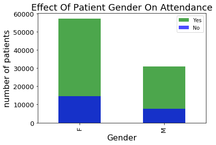

```python
Mycountplot(df,'Gender')
```

from the previous analysis:

It was found that more female patients than males.

The number of patients who did not attend 22314 includes (14591 females, or 65%, and 7,723 males, or 35%).

By reviewing the total number of patients who attended and did not attend, it was found that the percentage of non-attendance for both types is equal, which is 20% of the number of each.

### Research Question 3 (Does the patient's failure to reach the appointment message make him not attend?)

```python
df.groupby(['SMS_received','Show']).count()
```

| SMS_received | Show | PatientId | Gender | AppointmentDay | Age | Neighbourhood | Hipertension | WaitingTime | AppointmentDay_name |
| --- | --- | --- | --- | --- | --- | --- | --- | --- | --- |
| 0 | No | 12530 | 12530 | 12530 | 12530 | 12530 | 12530 | 12530 | 12530 |
|  | Yes | 62509 | 62509 | 62509 | 62509 | 62509 | 62509 | 62509 | 62509 |
| 1 | No | 9784 | 9784 | 9784 | 9784 | 9784 | 9784 | 9784 | 9784 |
|  | Yes | 25698 | 25698 | 25698 | 25698 | 25698 | 25698 | 25698 | 25698 |

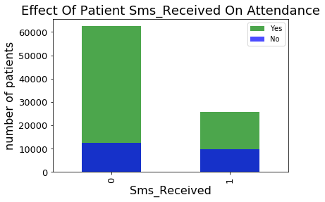

```python
Mycountplot(df,'SMS_received')
```

from the previous analysis:

71% of those present did not receive messages.

44% of those who did not attend received letters.

### Research Question 4 (Is it in the middle of the week when the patient is busy and cannot come for the appointment?)

```python
df.groupby(['AppointmentDay_name','Show']).count()
```

| AppointmentDay_name | Show | PatientId | Gender | AppointmentDay | Age | Neighbourhood | Hipertension | SMS_received | WaitingTime |
| --- | --- | --- | --- | --- | --- | --- | --- | --- | --- |
| Friday | No | 4037 | 4037 | 4037 | 4037 | 4037 | 4037 | 4037 | 4037 |
|  | Yes | 14982 | 14982 | 14982 | 14982 | 14982 | 14982 | 14982 | 14982 |
| Monday | No | 4689 | 4689 | 4689 | 4689 | 4689 | 4689 | 4689 | 4689 |
|  | Yes | 18024 | 18024 | 18024 | 18024 | 18024 | 18024 | 18024 | 18024 |
| Saturday | No | 9 | 9 | 9 | 9 | 9 | 9 | 9 | 9 |
|  | Yes | 30 | 30 | 30 | 30 | 30 | 30 | 30 | 30 |
| Thursday | No | 3337 | 3337 | 3337 | 3337 | 3337 | 3337 | 3337 | 3337 |
|  | Yes | 13909 | 13909 | 13909 | 13909 | 13909 | 13909 | 13909 | 13909 |
| Tuesday | No | 5150 | 5150 | 5150 | 5150 | 5150 | 5150 | 5150 | 5150 |
|  | Yes | 20488 | 20488 | 20488 | 20488 | 20488 | 20488 | 20488 | 20488 |
| Wednesday | No | 5092 | 5092 | 5092 | 5092 | 5092 | 5092 | 5092 | 5092 |
|  | Yes | 20774 | 20774 | 20774 | 20774 | 20774 | 20774 | 20774 | 20774 |

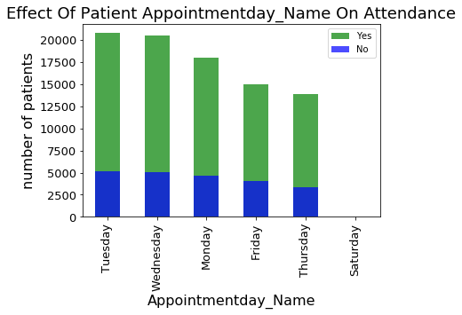

```python
Mycountplot(df,'AppointmentDay_name')
```

from the previous analysis:

On Sunday there are no medical appointments and The number of appointmentson Saturday is very low.

Non-attendance rates are not affected by days, as they range from 19% to 21%.

### Research Question 5 (What is the percentage of patients who did not attend and have Hypertension?)

```python
df.groupby(['Hipertension','Show']).count()
```

| Hipertension | Show | PatientId | Gender | AppointmentDay | Age | Neighbourhood | SMS_received | WaitingTime | AppointmentDay_name |
| --- | --- | --- | --- | --- | --- | --- | --- | --- | --- |
| 0 | No | 18542 | 18542 | 18542 | 18542 | 18542 | 18542 | 18542 | 18542 |
|  | Yes | 70178 | 70178 | 70178 | 70178 | 70178 | 70178 | 70178 | 70178 |
| 1 | No | 3772 | 3772 | 3772 | 3772 | 3772 | 3772 | 3772 | 3772 |
|  | Yes | 18029 | 18029 | 18029 | 18029 | 18029 | 18029 | 18029 | 18029 |

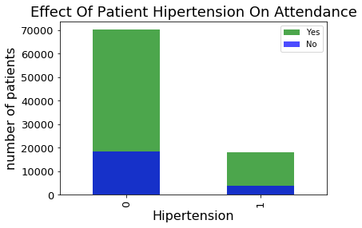

```python
Mycountplot(df,'Hipertension')
```

from the previous analysis:

it became clear that the patients who had Hypertension and did not attend the examination accounted for 16.9% of the total number of patients who did not attend the examination.

### Research Question 6 (What effect does WaitingTime have on patient attendance?)

```python
df.groupby(['WaitingTime','Show']).count()
```

| WaitingTime | Show | PatientId | Gender | AppointmentDay | Age | Neighbourhood | Hipertension | SMS_received | AppointmentDay_name |
| --- | --- | --- | --- | --- | --- | --- | --- | --- | --- |
| 0 | No | 1792 | 1792 | 1792 | 1792 | 1792 | 1792 | 1792 | 1792 |
|  | Yes | 36770 | 36770 | 36770 | 36770 | 36770 | 36770 | 36770 | 36770 |
| 1 | No | 1113 | 1113 | 1113 | 1113 | 1113 | 1113 | 1113 | 1113 |
|  | Yes | 4100 | 4100 | 4100 | 4100 | 4100 | 4100 | 4100 | 4100 |
| 2 | No | 1602 | 1602 | 1602 | 1602 | 1602 | 1602 | 1602 | 1602 |
| ... | ... | ... | ... | ... | ... | ... | ... | ... | ... |
| 169 | Yes | 7 | 7 | 7 | 7 | 7 | 7 | 7 | 7 |
| 176 | No | 6 | 6 | 6 | 6 | 6 | 6 | 6 | 6 |
|  | Yes | 10 | 10 | 10 | 10 | 10 | 10 | 10 | 10 |
| 179 | No | 2 | 2 | 2 | 2 | 2 | 2 | 2 | 2 |
|  | Yes | 8 | 8 | 8 | 8 | 8 | 8 | 8 | 8 |

235 rows × 8 columns

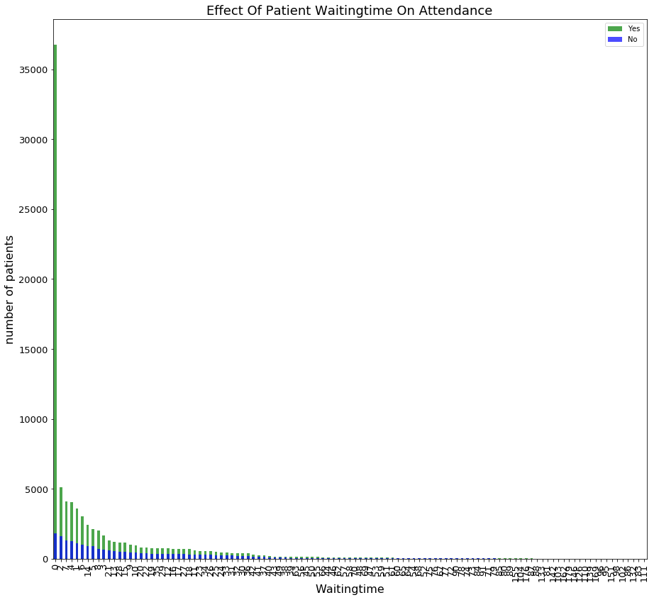

```python
plt.figure(figsize=[15,14])
Mycountplot(df,'WaitingTime')
```

from the previous analysis:

The largest number of patients who did not have WaitingTime are 36,770, or 42% of the total number of attendees.

Patients with 1 WaitingTime had a no-show rate of 21% of the total appointments for the day, which is a high percentage.

In principle, we note that patients who have a waiting time number have a large non-attendance rate.

### Research Question 7 (Is there a relationship between Neighborhood and attending the appointment?)

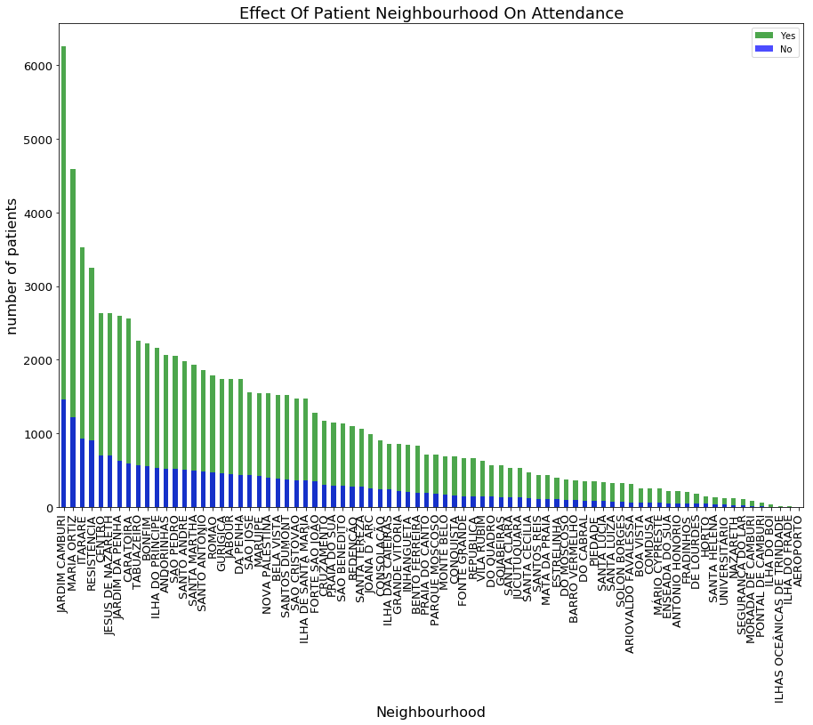

```python
plt.figure(figsize=[15,10])
Mycountplot(df,'Neighbourhood')
```

### Research Question 8 (Is there a relationship between the patient's age and attendance to the appointment?)

```python
df.groupby(['Age','Show']).count()
```

| Age | Show | PatientId | Gender | AppointmentDay | Neighbourhood | Hipertension | SMS_received | WaitingTime | AppointmentDay_name |
| --- | --- | --- | --- | --- | --- | --- | --- | --- | --- |
| 0 | No | 639 | 639 | 639 | 639 | 639 | 639 | 639 | 639 |
|  | Yes | 2900 | 2900 | 2900 | 2900 | 2900 | 2900 | 2900 | 2900 |
| 1 | No | 415 | 415 | 415 | 415 | 415 | 415 | 415 | 415 |
|  | Yes | 1858 | 1858 | 1858 | 1858 | 1858 | 1858 | 1858 | 1858 |
| 2 | No | 252 | 252 | 252 | 252 | 252 | 252 | 252 | 252 |
| ... | ... | ... | ... | ... | ... | ... | ... | ... | ... |
| 99 | Yes | 1 | 1 | 1 | 1 | 1 | 1 | 1 | 1 |
| 100 | Yes | 4 | 4 | 4 | 4 | 4 | 4 | 4 | 4 |
| 102 | Yes | 2 | 2 | 2 | 2 | 2 | 2 | 2 | 2 |
| 115 | No | 3 | 3 | 3 | 3 | 3 | 3 | 3 | 3 |
|  | Yes | 2 | 2 | 2 | 2 | 2 | 2 | 2 | 2 |

203 rows × 8 columns

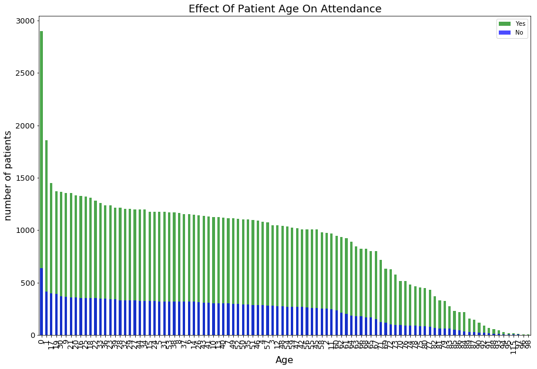

```python
plt.figure(figsize=[15,10])
Mycountplot(df,'Age')
```

## Conclusions

1-Patient attendance is 80%, while non-attendance is 20%.

2-The percentage of male and female patients who did not attend is equal and represents 20% of their number.

3-The number of patients who did not attend was 22314 includes (12530 did not receive messages by 56% and 9784 received messages by 44%),62,509 patients attended the appointment and did not receive any messages, which is 71% of the attendance rate.

4-On Sunday, there are no medical appointments and The number of appointmentson Saturday is very low ,Non-attendance rates are not affected by days, as they range from 19% to 21%.

5-the patients who had Hypertension and did not attend the examination accounted for 16.9% of the total number of patients who did not attend the examination.

6-The largest number of patients who did not have WaitingTime are 36,770, or 42% of the total number of attendees.

Patients with 1 WaitingTime had a no-show rate of 21% of the total appointments for the day, which is a high percentage.

In principle, we note that patients who have a waiting time number have a large non-attendance rate.

7-With regard to age and location, we did not notice any effect on the data

From all of the above, I see that the waitingtime can influence the patient's non-attendance. And I think that other data should have been available such as the specialization of the examination (inner, ear, nose, .....) and also the examination time (noon, early morning, night), as well as the name of the doctor and the number of patients he has

```python
from subprocess import call
call(['python', '-m', 'nbconvert', 'Investigate_a_Dataset.ipynb'])
```

```
0
```